# CITS4009 - Project 2

## Classification Summary

### Model Performance

The best performing model is the logistic regression model with PCA features which scored a perfect score in accuracy, precision and recall. This is not normal behavior for classifiers as in the real world, we rarely see classifiers achieve perfect scores. However, this could be explained by looking at the biplot of the first 2 principal components that was plotted in the feature selection, we observed that just in the first 2 principal components, the data was linearly separable. As we move to higher dimensional spaces by adding other principal components, it might have given use even better separation of the classes which led to the unlikely result of a perfect classifier.

This is also supported by the fact that on average, the logistic regression classifiers outperformed the decision tree classifiers. Therefore, for the purposes of this classification task, logistic regression seems to be the most suitable.

### Feature Importances

Both logistic regression and decision trees are inteprable classifiers.

Logistic regression, for binary classification, predicts the probability that a given instance belongs to a particular category based on a linear combination of its features. The model assigns a weight to each feature, and the sign and magnitude of this weight provide information about how the feature affects the outcome.

The decision tree structure is intuitive, with decisions being made at each node based on a single feature. This mirrors human decision-making in some contexts where we use a series of “if-then-else” conditions. As seen earlier, we can visualize this tree to have a clear overview of the decision making process in the model.

- Logistic Regression: `Country`, `video_views_rank` and `channel_type` were the most important features with `video.views` and `subscribers`receiving very little weight in all the models trained.
- Decision Tree: `video_views` and `uploads` were by far the most impact feature, with it being use to make multiple splits in the same tree. This is completely opposite to the logistic regression models which gave very little weight to these 2 features.

# Clustering

## Data preparation

We will be using the cleaned dataset and removing the target variable for clustering. We will also scale the data to have a mean value of 0 and a standard deviation of 1. This makes use of the `transform_cols()` function that was defined at the beginning of this document.

```r
youtube_clustering <- subset(youtube_cleaned, select=-c(average_yearly_earnings.binary))
youtube_clustering <- transform_cols(youtube_clustering, colnames(youtube_clustering), "norm")
```

## Hierarchical Clustering

```r
plot_dendrogram <- function(distMetric, linkageMethod, k){
  d <- dist(youtube_clustering, method=distMetric)
  pfit <- hclust(d, method=linkageMethod)
  plot(pfit, main="Cluster Dendrogram for Youtube Channels", labels=FALSE)
  rect.hclust(pfit, k=k)

  return(pfit)
}
```

We will now explore several different linkage criteria for plotting dendrograms.

### Hierarchical Clustering using single linkage

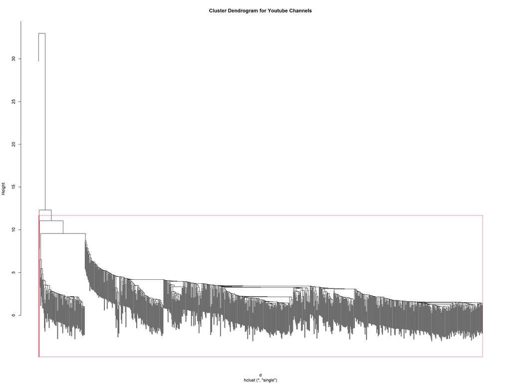

```r
pfit <- plot_dendrogram("manhattan", "single", 3)
```

In single linkage, we treat each data point as a single cluster. Therefore, if there are N data points, we start with N clusters. In each of the subsequent stages, the two clusters that are closest to each other are merged into a single cluster, reducing the total number of clusters by one.The distance between two clusters is determined by the shortest distance between points in the two clusters.

One of the main features of single linkage clustering is its ability to detect elongated or non-elliptical shaped clusters. However, it also has a tendency to create “chained” clusters where clusters can be long and “stringy”, potentially linking together clusters that are quite far apart in the broader dataset. This is because only the minimum pairwise distance matters and can lead to the “chaining effect”.

This can be observed in the plot of the dendrogram above. `Daddy Yankee` is very separated from the remainder of the instances in the dataset and only merges at a high distance value. For the rest of the observations, the dendrogram displays the chaining effect typical of single linkage, where clusters can be long and “stringy.” This effect is especially noticeable in the right cluster, where many subclusters merge at a low height, forming a long chain.

### Hierarchical Clustering using complete linkage

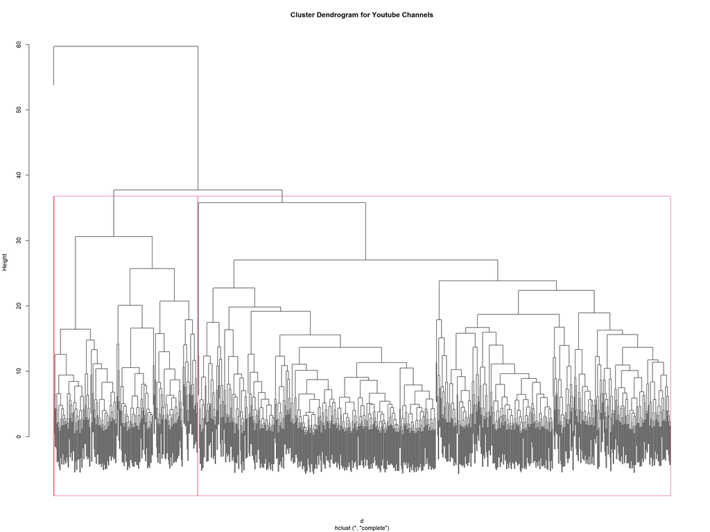

```r
pfit <- plot_dendrogram("manhattan", "complete", 3)
```

Complete linkage considers the distance between two clusters to be equal to the greatest distance from any member of one cluster to any member of the other cluster. The distance between two clusters is equal to the farthest points between them.

Compared to other linkage methods such as single linkage or average linkage, complete linkage tends to produce more balanced and compact clusters. However, it can also be sensitive to outliers, as a single outlying point can influence the distance between two clusters.

We can observe this in the dendrogram above, where we once again see the outlier `Daddy Yankee` at the top of the dendrogram. However, unlike single linkage, complete linkage produced a much more balanced dendrogram with no stringy trees.

### Hierarchical Clustering using ward.D2

Clustering using `ward.D2`:

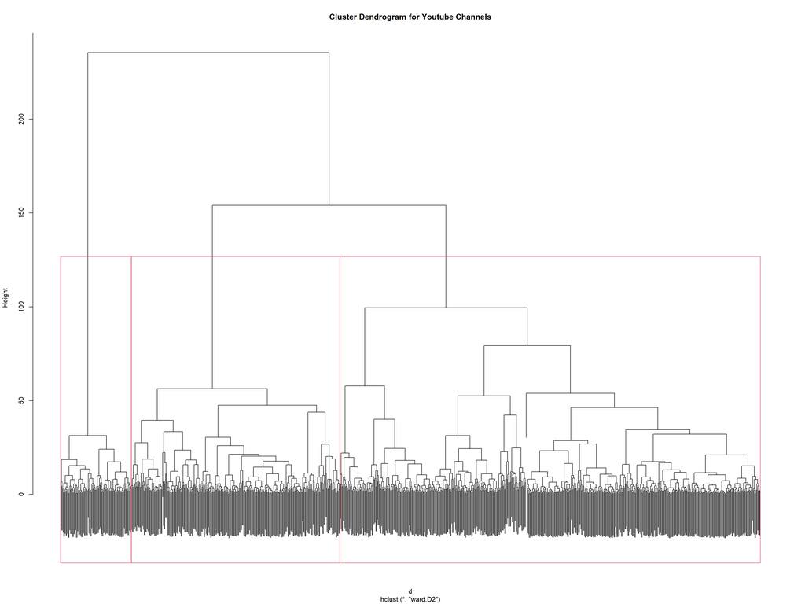

```r
pfit <- plot_dendrogram("manhattan", "ward.D2", 3)
```

The main goal of ward.D2 is to minimize the increase in total within-cluster variance after merging two clusters. In other words, it finds the pair of clusters to merge such that the sum of squared distances between the items and the centroids of their respective clusters increases the least.

Ward’s method often results in clusters that are relatively compact and roughly equal in size. However, it assumes that clusters have a roughly spherical shape in the data space. Like other methods, it can sometimes be sensitive to outliers.

Ward’s method produced the most balanced tree with 3 distinct, well separated clusters. However, the clusters are not equal in size. As this produced the most balanced dendrogram, we will be using the ward.D2 clustering method for the remainder of this document.

## Extracting members using cutree()

cutree() takes in a clustering model (e.g., created by hclust()) and returns a vector (or matrix) of cluster group assignment(s) for each row

```r
plot_instances <- function(df, x_col, group_vec) {

  # Check if x_col exists in df
  if (!x_col %in% colnames(df)) {
    stop("The specified x_col does not exist in the dataframe")
  }
  df$Group <- group_vec

  agg_data <- df %>%
    group_by(!!sym(x_col), Group) %>%
    summarise(Count = n()) %>%
    ungroup()

  agg_data <- agg_data %>%
    arrange(Count) %>%
    mutate(!!sym(x_col) := factor(!!sym(x_col), levels = unique(!!sym(x_col))))

  # Plotting
  p <- ggplot(agg_data, aes_string(y = x_col, x = "Count", fill = "as.factor(Group)")) +
    geom_bar(stat = "identity", position = "stack") +
    labs(title = paste0("Number of Instances by ", x_col, " and Group"),
         x = "Number of Instances",
         y = x_col,
         fill = "Group") +
    theme_minimal() +
    theme(axis.text.y = element_text(hjust = 1))

  return(p)
}
```

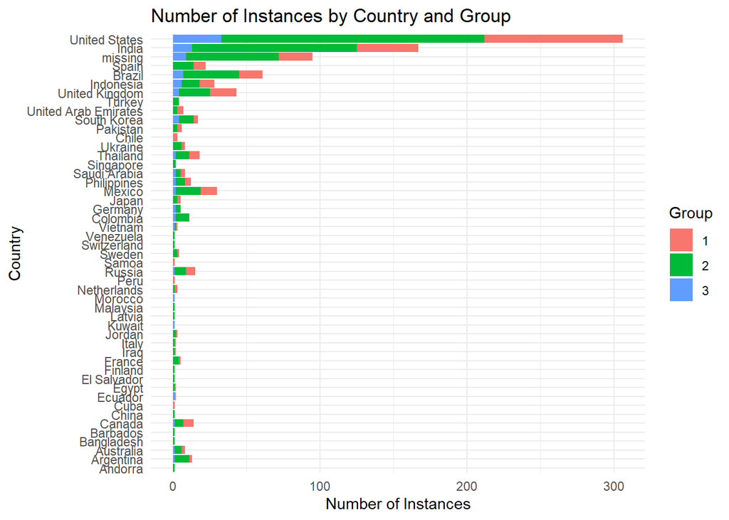

```r
groups <- cutree(pfit, k=3)
plot_instances(names, "Country", groups)
```

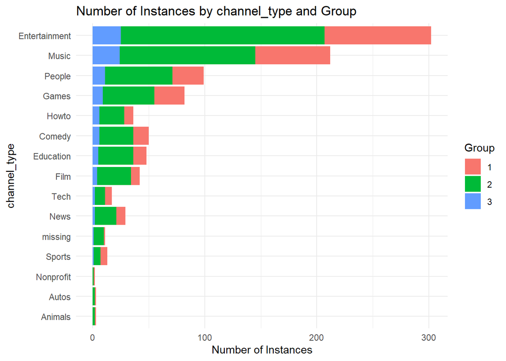

```r
plot_instances(names, "channel_type", groups)
```

We are unable to extract much useful information from the clusters when plotting by `Country` or `Category`. As seen in the plots above, each variable is made of a mix of the three clusters. It is hard to glean any useful information from them.

## Visualising Clusters

```r
groups <- cutree(pfit, k=2)
princ <- prcomp(youtube_clustering)
nComp <- 2
project2D <- as.data.frame(predict(princ, newdata=youtube_clustering)[,1:nComp])
hclust.project2D <- cbind(project2D, cluster=as.factor(groups), country=names$Country)
head(hclust.project2D)
```

```
##          PC1      PC2 cluster       country
## 1 -1.5277064 5.778019       1         India
## 2 -1.3214428 2.339898       1 United States
## 3 -1.9552719 3.362344       1 United States
## 5 -1.4747655 2.549756       1         India
## 6 -0.6438988 3.515180       1 United States
## 7 -0.9070423 3.183077       1         Japan
```

```r
library('grDevices')
find_convex_hull <- function(proj2Ddf, groups) {
  do.call(rbind,
    lapply(unique(groups),
      FUN = function(c) {
        f <- subset(proj2Ddf, cluster==c);
        f[chull(f),]
      }
    )
  )
}
hclust.hull <- find_convex_hull(hclust.project2D, groups)
```

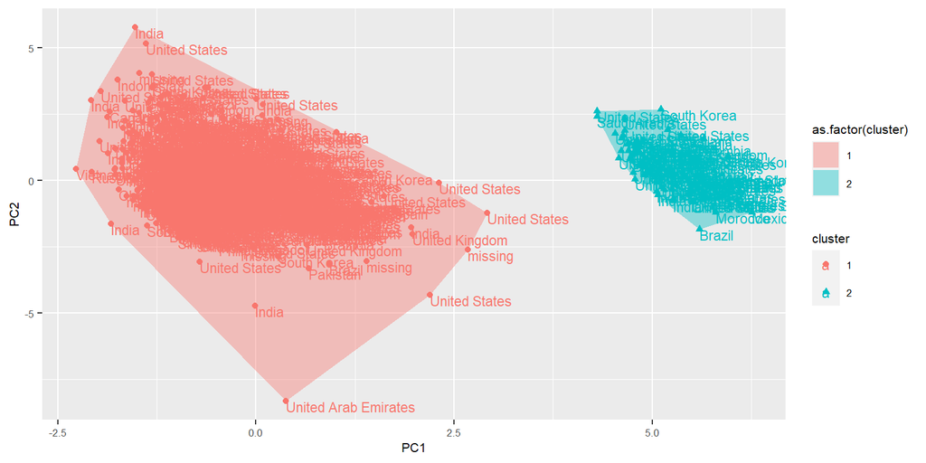

```r
ggplot(hclust.project2D, aes(x=PC1, y=PC2)) +
geom_point(aes(shape=cluster, color=cluster)) +
geom_text(aes(label=country, color=cluster), hjust=0, vjust=1, size=3) +
geom_polygon(data=hclust.hull, aes(group=cluster, fill=as.factor(cluster)),
alpha=0.4, linetype=0) + theme(text=element_text(size=8))
```

## Using clusterboot() to assess stability

```r
kbest.p <- 3
cboot.hclust <- clusterboot(youtube_clustering, clustermethod=hclustCBI,
method="ward.D2", k=kbest.p)
```

```r
summary(cboot.hclust$result)
```

```
##               Length Class  Mode
## result          7    hclust list
## noise           1    -none- logical
## nc              1    -none- numeric
## clusterlist     3    -none- list
## partition     949    -none- numeric
## clustermethod   1    -none- character
## nccl            1    -none- numeric
```

```r
groups.cboot <- cboot.hclust$result$partition
values <- 1 - cboot.hclust$bootbrd/100
```

## Finding the value of k

```r
# Function to return the squared Euclidean distance of two given points x and y
sqr_euDist <- function(x, y) {
  sum((x - y)^2)
}

# Function to calculate WSS of a cluster, represented as a n-by-d matrix
# (where n and d are the numbers of rows and columns of the matrix)
# which contains only points of the cluster.
wss <- function(clustermat) {
  c0 <- colMeans(clustermat)
  sum(apply( clustermat, 1, FUN=function(row) {sqr_euDist(row, c0)} ))
}

# Function to calculate the total WSS. Argument `scaled_df`: data frame
# with normalised numerical columns. Argument `labels`: vector containing
# the cluster ID (starting at 1) for each row of the data frame.
wss_total <- function(scaled_df, labels) {
  wss.sum <- 0
  k <- length(unique(labels))
  for (i in 1:k)
      wss.sum <- wss.sum + wss(subset(scaled_df, labels == i))
  wss.sum
}

# Function to calculate total sum of squared (TSS) distance of data
# points about the (global) mean. This is the same as WSS when the
# number of clusters (k) is 1.
tss <- function(scaled_df) {
  wss(scaled_df)
}

# Function to return the CH indices computed using hierarchical
# clustering (function `hclust`) or k-means clustering (`kmeans`)
# for a vector of k values ranging from 1 to kmax.
CH_index <- function(scaled_df, kmax, method="kmeans") {
  if (!(method %in% c("kmeans", "hclust")))
    stop("method must be one of c('kmeans', 'hclust')")
  npts <- nrow(scaled_df)
  wss.value <- numeric(kmax) # create a vector of numeric type
  # wss.value[1] stores the WSS value for k=1 (when all the
  # data points form 1 large cluster).
  wss.value[1] <- wss(scaled_df)

  if (method == "kmeans") {
    # kmeans
    for (k in 2:kmax) {
    clustering <- kmeans(scaled_df, k, nstart=10, iter.max=100)
    wss.value[k] <- clustering$tot.withinss
    }
  } else {
    # hclust
    d <- dist(scaled_df, method="euclidean")
    pfit <- hclust(d, method="ward.D2")
    for (k in 2:kmax) {
      labels <- cutree(pfit, k=k)
      wss.value[k] <- wss_total(scaled_df, labels)
    }
  }
  bss.value <- tss(scaled_df) - wss.value # this is a vector
  B <- bss.value / (0:(kmax-1)) # also a vector
  W <- wss.value / (npts - 1:kmax) # also a vector
  data.frame(k = 1:kmax, CH_index = B/W, WSS = wss.value)
}
```

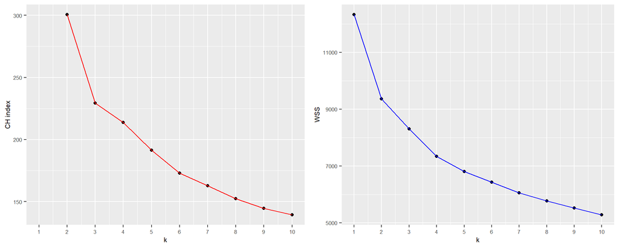

```r
# calculate the CH criterion
crit.df <- CH_index(youtube_clustering, 10, method="hclust")

fig1 <- ggplot(crit.df, aes(x=k, y=CH_index)) +
  geom_point() + geom_line(colour="red") +
  scale_x_continuous(breaks=1:10, labels=1:10) +
  labs(y="CH index") + theme(text=element_text(size=8))

fig2 <- ggplot(crit.df, aes(x=k, y=WSS), color="blue") +
  geom_point() + geom_line(colour="blue") +
  scale_x_continuous(breaks=1:10, labels=1:10) +
  theme(text=element_text(size=8))

grid.arrange(fig1, fig2, nrow=1)
```